# lshin_hw2_markdown

Lucas Shin

9/30/2020

# 1

```r
babynames %>%
   group_by(name) %>%
   summarize(total = sum(n)) %>%
   arrange(-total) %>%
   head(10)
```

```
## # A tibble: 10 x 2
##    name      total
##    <chr>     <int>
##  1 James   5173828
##  2 John    5137142
##  3 Robert  4834915
##  4 Michael 4372536
##  5 Mary    4138360
##  6 William 4118553
##  7 David   3624225
##  8 Joseph  2614083
##  9 Richard 2572613
## 10 Charles 2398453
```

The top 10 most common baby names (for US babies) and the number of babies with each can be found below: James 5173828  
John 5137142  
Robert 4834915  
Michael 4372536  
Mary 4138360  
William 4118553  
David 3624225  
Joseph 2614083  
Richard 2572613  
Charles 2398453

# 2

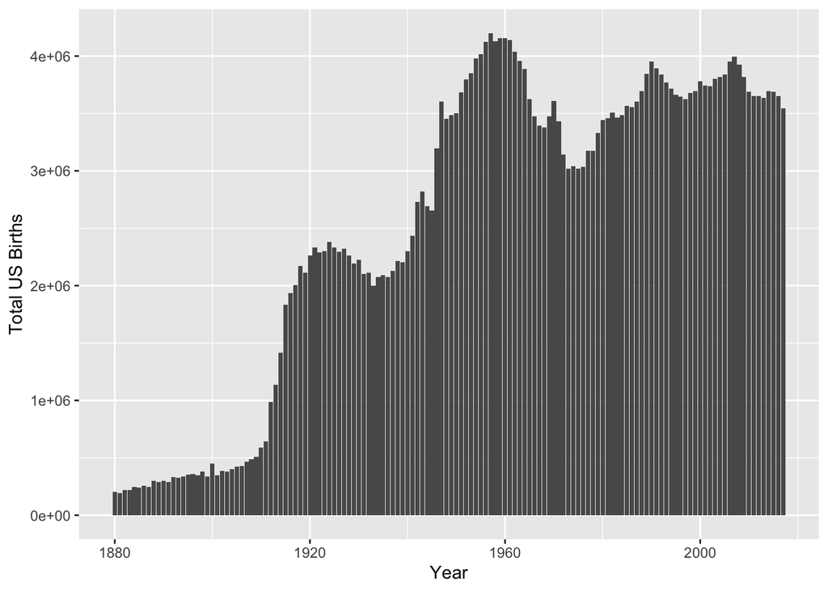

```r
babynames %>%
   select(year, n, prop) %>%
   filter(year >= 1880) %>%
   group_by(year) %>%
   ggplot(mapping = aes(x = year,
                        y = n)) +
   geom_bar(stat = "identity") +
   labs(x = "Year", y = "Total US Births")
```

As the graph above shows, the total US births have generally increased over time, with large spikes in births around 1920 and 1960 (each of these spikes was followed by drops in births in the following years). The overall upward trend in births can most likely be attributed to advancements in medicine and an increase in food availability. The decrease in births from the mid 1920s to around 1930 can be attributed to the Great Depression, when unemployment rates rose and people were struggling financially. The decrease in births from around 1960-1975 can be attributed to a change in societal standards (more opportunities given to women) and an increase and improvement in contraceptives.

# 3

```r
babynames %>%
   group_by(year) %>%
   filter(year == 2000) %>%
   summarize(total = sum(n))
```

```
## # A tibble: 1 x 2
##    year   total
##   <dbl>   <int>
## 1  2000 3778079
```

The US births in 2000 was approximately 4,059,000 (according to https://pubmed.ncbi.nlm.nih.gov/11876093/). The number of US births recorded by babynames in 2000 is 3,778,079.

The number of US births reported by the government in 2000 is about 300,000 greater than that reported by the SSA. I don’t think these values should be equal. According to the description of babynames, only names with at least 5 uses were reported. Thus, if an uncommon name was given to a baby, it was not included in this data set, so the total number of births should be lower than the total number reported by the government.

# 4

```r
babynames %>%
   group_by(name) %>%
   summarize(total = sum(n)) %>%
   filter(total>=1000) %>%
   mutate(numChar = str_length(name)) %>%
   arrange(-numChar)
```

```
## # A tibble: 10,570 x 3
##    name          total numChar
##    <chr>         <int>   <int>
##  1 Maryelizabeth  1969      13
##  2 Michaelangelo  1236      13
##  3 Konstantinos   1770      12
##  4 Marcoantonio   1467      12
##  5 Abdulrahman    2121      11
##  6 Alejandrina    1281      11
##  7 Alexzandria    1665      11
##  8 Bartholomew    4004      11
##  9 Charlesetta    1303      11
## 10 Chirstopher    1051      11
## # … with 10,560 more rows
```

Maryelizabeth and Michaelangelo are the two longest names given to at least 1,000 babies (each 13 letters long).

# 5

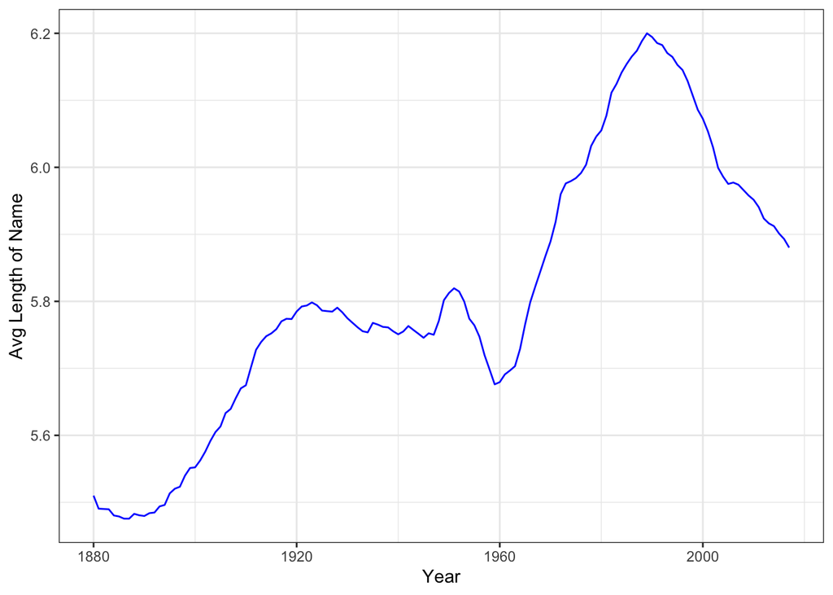

```r
babynames %>%
   mutate(count = str_length(name)) %>%
   mutate(chars = n*count) %>%
   group_by(year) %>%
   summarize(lengthOfNames = sum(chars)/sum(n)) %>%
   ggplot(mapping = aes(x = year,
                        y = lengthOfNames)) +
   geom_line(stat = "identity",
             color = "blue") +
   labs(x = "Year",
        y = "Avg Length of Name") +
   theme_bw()
```

As shown by the above graph, the average length of baby names in the US increased over time. Around 1950, there was a spike in average baby name lengths. Also, from 1960 to around 1990, there was another large increase in average length. After around 1990, the average length of baby names began to decrease.

# 6

First, I filtered through and grouped the data from babynames to find the baby names that changed most in femaleness from 1880 to 2017. I chose the 3 names that changed the most (Donnie, Leslie, Robbie.

```r
names <- babynames %>%
   filter(year %in% c("1880", "2017")) %>%
   select(year, sex, name, n) %>%
   group_by(name, year) %>%
   mutate(total = sum(n)) %>%
   mutate(propO = n/total)%>%
   filter(sex == "F") %>%
   group_by(name) %>%
   summarize(change = max(propO) - min(propO)) %>%
   filter(change > 0,
          change < 1) %>%
   arrange(-change) %>%
   head(3)
```

Then, I filtered through the data set again to see how much Donnie, Leslie, and Robbie decreased (or increased) in “femaleness” every year from 1880 to 2017.

```r
name3 <- babynames %>%
   group_by(year, name) %>%
   filter(name %in% c("Donnie", "Leslie", "Robbie")) %>%
   select(year, sex, name, n) %>%
   mutate(total = sum(n)) %>%
   mutate(prop = n/total) %>%
   filter(sex == "F")
```

Then, I graphed this proportion of “femaleness” over time, as shown below.

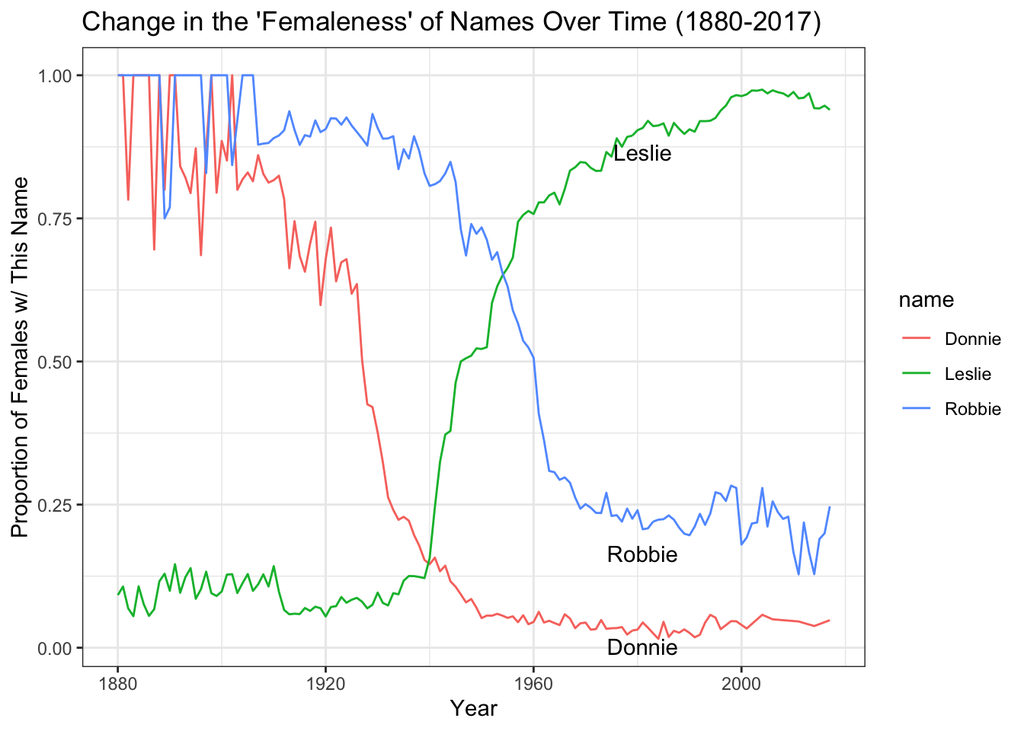

```r
name3 %>%
   ggplot(mapping = aes(x = year,
                     y = prop)) +
   geom_line(aes(color = name)) +
   geom_text(data = name3 %>% filter(year == "1981"),
             aes(label = name),
             vjust = 2) +
   xlab("Year") +
   ylab("Proportion of Females w/ This Name") +
   theme_bw() +
   labs(title = "Change in the 'Femaleness' of Names Over Time (1880-2017)")
```